# 1. SVM

## a. Margin

Explain why we can set the margin $c = 1$ to derive an equivalent SVM formulation.

In the optimization problem

$$ \max_{w,b} \frac{2c}{\Vert{w}\Vert} \\ s.t. y_i(w^\top x_i + b) \geq c, \forall i $$

$c$ represents the size of the margin. Its presence in both the maximization problem and the constraint means that it directly scales both $w$ and $b$ and can be treated as a constant in the optimization problem. Therefore, we can set $c = 1$, since the margin size is not being optimized.

## b. Weight vector

Using Lagrangian dual formulation, show that the weight vector can be represented as

$$ w = \sum_{i=1}^n \alpha_i y_i x_i $$

where $\alpha_i \geq 0$ are the dual variables. What does this imply in terms of how to relate data to $w$?

The dual formulation is:

$$ L(w, \alpha\, b) = \frac{1}{2}w^\top w + \sum_{i=1}^{m}\alpha_i\left(1 - y_i(w^\top x_i + b)\right) $$

To minimize this, we take the derivative:

$$\begin{align} \frac{\partial L}{\partial w} & = 2*\frac{1}{2}w + \sum_{i=1}^{m} \alpha_i (-y_i x_i ) \\ & = w - \sum_{i=1}^{m} \alpha_i y_i x_i \end{align}$$

then set to 0 and solve for a representation of $w$:

$$\begin{align} w & - \sum_{i=1}^{m} \alpha_i y_i x_i = 0 \\ w & = \sum_{i=1}^{m} \alpha_i y_i x_i \end{align}$$

This final representation of the weight vector $w$ implies that it is a linear combination of $\alpha_i$, $x_i$ (the input data), and $y_i$ (the class assigned during training).

## c. Data points on the margin

Explain why only the data points on the "margin" will contribute to the sum above, i.e. playing a role in defining $w$. Hint: use the Lagrangian multiplier derivation and KKT condition we discussed in class.

The KKT condition is $a_i g_i(w) = 0$, which can also be written as $a_i\left(1-y_i(w^\top x_i + b)\right) = 0$.

We also have the following facts:

- $y \in \{-1, 1\}$
- $w^\top x + b \in \{-1, 1\}$ (the margin edges parallel to the decision boundary)

Therefore, $y_i(w^\top x_i + b) = 1$ for points on the margin, meaning that $1-y_i(w^\top x_i + b) = 0$ for those points. For points off the margin, $1-y_i(w^\top x_i + b) < 0$.

For points on the margin, $\alpha_i > 0$; for those off the margin, $\alpha_i = 0$. Both will satisfy the KKT condition when the terms are multiplied.

However, because $w = \sum_{i=1}^{m} \alpha_i y_i x_i$, any point with $\alpha_i = 0$ (i.e. any point **off** the margin) will not contribute to the final value of $w$. Therefore, only points on the margin contribute to the sum.

# 2. Naive Bayes for spam filtering

In this problem, we will use the Naive Bayes algorithm to fit a spam filter by hand. This will enhance your understanding of Bayes classifier and build intuition.

Spam filters are used in all email services to classify received emails as "Spam" or "Not Spam". A simple approach involves maintaining a vocabulary of words that commonly occur in "Spam" emails and classifying an email as "Spam" if the number of words from the dictionary that are present in the email is over a certain threshold. We are given the vocabulary consisting of 15 words:

$V = \{$secret, offer, low, price, valued, customer, today, dollar, million, sports, is, for, play, healthy, pizza$\}$

We will use $V_i$ to represent the $i$th word in $V$. As our training dataset, we are also given 3 example spam messages:

- million dollar offer
- secret offer today
- secret is secret

and 4 example non-spam messages:

- low price for valued customer
- play secret sports today
- sports is healthy
- low price pizza

Recall that the Naive Bayes classifier assumes that the probability of an input $x = [x_1, x_2, \dots, x_n]^{\top}$ depends on its class $y$. In our case, the input vector $x$ corresponding to each message has length $n = 15$ equal to the number of words in the vocabulary $V$, where each entry $x_i$ is equal to the number of times word $V_i$ occurs in $x$.

## a. Prior probabilities

Calculate $\mathbb{P}(y=0)$ and $\mathbb{P}(y=1)$ from the training data, where $y=0$ corresponds to spam messages and $y=1$ corresponds to non-spam messages.

There are 7 total messages ($m = 7$).

- 3 **spam** messages $\Rightarrow p(y=0) = 3/7$
- 4 **non-spam** messages $\Rightarrow p(y=1) = 4/7$

## b. Feature vectors

List feature vector $x$ for each spam and non-spam message.

$V = \{$secret, offer, low, price, valued, customer, today, dollar, million, sports, is, for, play, healthy, pizza$\}$

Spam:

- million dollar offer: $[0, 1, 0, 0, 0, 0, 0, 1, 1, 0, 0, 0, 0, 0, 0]^\top$
- secret offer today: $[1, 1, 0, 0, 0, 0, 1, 0, 0, 0, 0, 0, 0, 0, 0]^\top$
- secret is secret: $[2, 0, 0, 0, 0, 0, 0, 0, 0, 0, 1, 0, 0, 0, 0]^\top$

Non-spam:

- low price for valued customer: $[0, 0, 1, 1, 1, 1, 0, 0, 0, 0, 0, 1, 0, 0, 0]^\top$
- play secret sports today: $[1, 0, 0, 0, 0, 0, 1, 0, 0, 1, 0, 0, 1, 0, 0]^\top$
- sports is healthy: $[0, 0, 0, 0, 0, 0, 0, 0, 0, 1, 1, 0, 0, 1, 0]^\top$
- low price pizza: $[0, 0, 1, 1, 0, 0, 0, 0, 0, 0, 0, 0, 0, 0, 1]^\top$

## c. Maximum likelihood estimates

In the Naive Bayes model, the likelihood of a sentence with feature vector $x$ given a class $c$ is

$$ \mathbb{P}(x|y=c) = \prod_{k=1}^n \theta_{c,k}^{x_k} $$

where $\theta_{c,k} \in (0,1)$ is the weight of word $k$ in class $c$, which satisfies $\sum_{k=1}^n \theta_{c,k} = 1, \forall c$. Calculate the maximum likelihood estimates of $\theta_{0,1}, \theta_{0,7}, \theta_{1,1}, \theta_{1,15}$ by maximizing $\mathbb{P}(x|y=c)$ with respect to $\theta_{c,k}$ and given data.

Hint: Consider the Lagrangian function for solving this constrained optimization problem. You only need to introduce one Lagrangian multiplier because you only have one constraint. Consider log-likelihood (i.e. taking the log of the cost function). Then solve it from there.

### i. Summary

The maximum likelihood estimates are:

- $\theta_{0,1}$ = 0.333, or 3/9
- $\theta_{0,7}$ = 0.111, or 1/9
- $\theta_{1,1}$ = 0.067, or 1/15
- $\theta_{1,15}$ = 0.067, or 1/15

The full derivation and explanation is below.

### ii. Derivation

In training a Naive Bayes classifier, we want a model $p(y=c|x)$ for class $c$.

By Bayes' theorem:

$$\begin{align} p(y=c|x) = \frac{p(x|y=c) p(y=c)}{p(x)} \end{align}$$

For the purpose of learning the model, we only care about the numerator $p(x|y=c) p(y=c)$ because the denominator is effectively a constant in the training process. Therefore, our problem becomes:

$$\begin{align} p(y=c|x) = p(x|y=c) p(y=c) = p(x,y) \end{align}$$

With the assumption of independence and the chain rule of probability:

$$\begin{align} p(y=c|x) = p(x,y) & = p(x_1, x_2, \dots x_n, y=c) \\ & = p(y=c) \prod_{k=1}^{n} p(x|y=c) \\ & = p(y=c) \prod_{k=1}^{n} \theta_{c,k}^{x_k}, \end{align}$$

where $n$ is the number of features (i.e. 15 - one for each word).

Across all points in the training set, the equation becomes:

$$\begin{align} p(x, y) = \prod_{i=1}^{m} p(y_i=c) \prod_{k=1}^{n} \theta_{c,k}^{x_{i_k}} \end{align}$$

$p(y=c)$ can also be expressed as a combination of the two probabilities: $p(y=1)^c p(y=0)^{1-c}$, and the equation can be expressed in log-space to simplify optimization:

$$\begin{align} log[p(x, y)] & = \sum_{i=1}^{m} log\left[ p(y_i=c) \prod_{k=1}^{n} \theta_{c,k}^{x_{i_k}} \right] \\ & = \sum_{i=1}^{m} log\left[ p(y=1)^c p(y=0)^{1-c} \prod_{k=1}^{n} \theta_{c,k}^{x_{i_k}} \right] \\ & = \sum_{i=1}^{m} log\left[ p(y=1)^c p(y=0)^{1-c} + \sum_{k=1}^{n} log(\theta_{c,k}^{x_{i_k}}) \right] \end{align}$$

The function above is also subject to the constraint $\sum_{k=1}^{n} \theta_{c,k} = 1$. In order to optimize it, we can use the method of Lagrange multipliers. In general, $L(x,\lambda) = f(x) + \lambda g(x) \ s.t. \ g(x) = 0$; in this case, the equality constraint $g(x) = 1$ can be expressed as $g(x) - 1 = 0$. Therefore, the Lagrangian function for constrained optimization is:

$$\begin{align} L[p(x,y)] = \sum_{i=1}^{m} \left( log \left[ p(y=1)^c p(y=0)^{1-c} + \sum_{k=1}^{n} log(\theta_{c,k}^{x_{i_k}}) \right] + \lambda \left[ \sum_{k=1}^{n} \theta_{c,k} - 1 \right] \right) \end{align}$$

In order to maximize, we take the derivative and set it to zero:

$$\begin{align} \frac{\partial L}{\partial \theta_{c,k}} = \sum_{i=1}^{m} \frac{x_k}{\theta_{c,k}} (y=c) + \lambda \end{align}$$

Here, $(y=c)$ is an indicator variable whose value is 1 if $y=c$ and 0 if $y \neq c$.

$$\begin{align} \sum_{i=1}^{m} \frac{x_k}{\theta_{c,k}} (y=c) + \lambda & = 0 \\ \frac{1}{\theta_{c,k}} \sum_{i=1}^{m} x_k (y=c) + \lambda & = 0 \\ {\theta_{c,k}} & = -\frac{1}{\lambda} \sum_{i=1}^{m} x_k (y=c) \end{align}$$

Using the constraint/identity $\sum_{k=1}^{n} \theta_{c,k} = 1$:

$$\begin{align} - \frac{1}{\lambda} \sum_{k=1}^{n} \sum_{i=1}^{m} x_k (y=c) & = 1 \\ - \sum_{k=1}^{n} \sum_{i=1}^{m} x_k (y=c) & = \lambda \end{align}$$

Substituting this back into the formula for $\theta_{c,k}$ returns this expression of the weight $\theta_{c,k}$:

$$\begin{align} \theta_{c,k} = \frac{-\sum_{i=1}^{m} x_k (y=c)}{-\sum_{k=1}^{n} \sum_{i=1}^{m} x_k (y=c)} = \frac{\sum_{i=1}^{m} x_k (y=c)}{\sum_{k=1}^{n} \sum_{i=1}^{m} x_k (y=c)} \end{align}$$

In plain English, this is equivalent to:

- The number of occurrences of word $k$ across all data points in class $c$,
- Divided by the total number of occurrences of all words, across all data points in class $c$

This is fairly intuitive as well: the contribution of each word is proportional to its representation among the sentences that make up a given class.

Using this definition of $\theta_{c,k}$, I calculated the following values:

- $\theta_{0,1}$ = 0.333, or 3/9
- $\theta_{0,7}$ = 0.111, or 1/9
- $\theta_{1,1}$ = 0.067, or 1/15
- $\theta_{1,15}$ = 0.067, or 1/15

The included Excel spreadsheet `Q2.xlsx` shows the calculations as well.

## d. Classification

Given a new message "today is secret", decide whether it is spam or not spam based on the Naive Bayes classifier learned from the above data.

### i. Summary

"today is secret" is classified as **spam** with a joint probability/numerator of ~0.00176 vs. ~0.00017 for non-spam. A more detailed explanation is below.

### ii. Explanation

From the Bayes' theorem, we have $p(y|x) = \frac{p(x|y)p(y)}{p(x)}$. For assigning a class, we take the $argmax$ of $p(y|x)$: choose the class with the greater value.

For the purposes of classification, only the numerator is important, since $p(x)$ will be identical for each class' model. Therefore, selecting a class only requires comparing the numerators:

- $p(x|y=0)p(y=0)$
- $p(x|y=1)p(y=1)$

From part c, we know that $p(x|y=c)$ is defined as $\prod_{k=1}^{n} \theta_{c,k}^{x_{i_k}}$. Therefore, the numerator (which is equivalent to the joint probability $p(x,y=c)$ can be expressed as:

$$ p(y=c) \prod_{k=1}^{n} \theta_{c,k}^{x_{i_k}} $$

After calculating the values of $\theta_{c,k}$ for every word in both classes, the joint probabilities are:

- 0.00176367 for spam ($y=0$)
- 0.00016931 for non-spam ($y=1$)

Spam has a greater probability, so the message is classified as spam.

The included Excel spreadsheet `Q2.xlsx` shows the calculations in detail.

# 3. Comparing Bayes, logistic, and KNN classifiers

In the lectures, we learned three different classifiers. This question is to implement and compare them. We suggest using `scikit-learn`, which is a commonly used and powerful Python library with various machine learning tools. But you can also use other similar libraries in other languages of your choice to perform the tasks.

## a. Divorce classification/prediction

This dataset is about participants who completed the personal information form and a divorce predictors scale.

The data is a modified version of the publicly available dataset at https://archive.ics.uci.edu/ml/datasets/Divorce+Predictors+data+set (by injecting noise so you will not replicate the results on the UCI website). There are 170 participants and 54 attributes (or predictor variables) that are all real-valued in the dataset `q3.csv`.

The last column of the CSV file is label $y$ ($1$ means "divorce", $0$ means "no divorce").

Each column is for one feature (predictor variable) and each row is a sample (participant). A detailed explanation for each feature (predictor variable) can be found at the website link above.

Our goal is to build a classifier using training data, such that given a test sample, we can classify (or essentially predict) whether its label is $0$ ("no divorce") or $1$ ("divorce").

Build three classifiers using Naive Bayes, logistic regression, and KNN. Use the first 80% of data for training and the remaining 20% for testing. If you use `scikit-learn`, you can use `train_test_split` to split the dataset.

### i. Testing accuracy

Report testing accuracy for each of the three classifiers. Comment on their performance: which performs the best, and make a guess why they perform the best in this setting.

Below are the results from my classifiers:

| Classifier | Testing Accuracy (Divorce) |
| --- | --- |
| Naive Bayes | 100% |
| Logistic regression | 91.2% |
| KNN | 100% |

Naive Bayes and KNN both performed the best, with 100% each. My guess is that they perform better because they can generate nonlinear decision boundaries, and this data is not completely linearly separable.

### ii. Classifiers on two features

Use the first two features to train three new classifiers. Plot the data points and decision boundary of each classifier. Comment on the difference between the decision boundary for the three classifiers. Please clearly represent the data points with different labels using different colors.

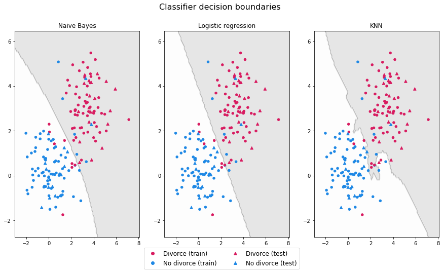

Additionally, testing accuracies for the two-feature classifiers are below:

| Classifier | Testing Accuracy (Divorce) |
| --- | --- |
| Naive Bayes | 94.1% |
| Logistic regression | 94.1% |
| KNN | 88.2% |

My observations:

- The decision boundary for Naive Bayes is somewhat nonlinear.
- The decision boundary for logistic regression is linear.
- The decision boundary for KNN is very nonlinear.
- The decision boundary for KNN seems to classify some "No divorce" points incorrectly in order to classify the some outlying "Divorce" points. This may explain the lower testing accuracy for KNN.
- The decision boundaries for Naive Bayes and logistic regression are similar, which may explain their equivalent testing accuracies.

## b. Handwritten digits classification

Repeat the above using the MNIST data from our previous homework. Here, give "digit" 6 label $y=1$ and give "digit" 2 label $y=0$. All the pixels in each image will be the feature (predictor variables) for that sample (i.e. image).

Our goal is to build a classifier such that given a new test sample, we can tell if it is a 2 or a 6. Using the first 80% of the samples for training and remaining 20% for testing, repoert the classification accuracy on testing data fore ach of the three classifiers. Comment on their performance: which performs the best and make a guess why they perform the best in this setting.

| Classifier | Testing Accuracy (Digits) |
| --- | --- |
| Naive Bayes | 77.4% |
| Logistic regression | 97.2% |
| KNN | 99.0% |

KNN performs best, followed by logistic regression and Naive Bayes. My guess is that Naive Bayes performs the worst because this classifier was specifically trained using `scikit-learn`'s `GaussianNB` classifier. This classifier assumes a Gaussian distribution, which might not be true of the underlying data.

KNN may perform better than logistic regression because logistic regression's decision boundary is linear, and the features are not linearly separable. I also note that I trained a classifier using the default value of k (`n_neighbors` = 5), and the difference in accuracy between KNN and the other classifiers could vary.